# Data wrangling + plotting regression

```r
library(broom)
library(tidyverse)
```

## Merging data

### Concatenating data

Two (or more) vectors / data frames / tibbles can be easily combined with `cbind()` (bind by columns) or `rbind()` (bind by rows). Their tidyverse equivalents are `bind_cols()` and `bind_rows()`.

While cbind puts the columns of the data frames next to each other, it’s not required that these data frames have an equal number of rows. For example, when combining data frames df1 and df2 of different length, the shorter just gets recycled.

```r
# shorter vector/data frame gets recycled
short_df <- tibble(x = 1:2)
long_df <- tibble(x = 1:8)

cbind(short_df, long_df) %>%
  data.frame() # when transforming to data frame, columns cannot have equal names

# rbind doesn't recycle
wide_df <- tibble(x = 1:2, y = 3:4)
rbind(short_df, wide_df)
```

In bind_cols, the number of rows needs to be equal. In bind_rows, columns are matched by name (similarly to rbind), and any missing columns will be filled with NA.

```r
wider_df <- tibble(y = 3:4, x = 5:6, z = 7:8)

bind_rows(wide_df, wider_df) # first 2 rows of z = NA
```

### Matching by value

What if we wanted to combine data frames by *value*, not by position? For example, we would like to combine long_df (consisting of x) and wide_df (x and y). They have a **common column x**, which will be used for matching.

We can use one of `full_join()`, `left_join()`, `right_join()`, or `inner_join()`. Let’s see what each of these does:

```r
long_df
wide_df

full_join(long_df, wide_df) # removes nothing from either data frame

left_join(long_df, wide_df) # removes nothing from the left data frame (long_df)

right_join(long_df, wide_df) # removes nothing from the right data frame (wide_df)

inner_join(long_df, wide_df) # removes all "excess" rows from both data frames (i.e. where values of x don't match)
```

[output not shown]

The base R equivalent of these operations is `merge()`, which also works well, and makes an inner join by default. However, making other kinds of joins with it can be tedious. In merge, the left data frame is x and the right is y.

```r
merge(long_df, wide_df, all = TRUE) # removes nothing from either data frame

merge(long_df, wide_df, all.x = TRUE) # removes nothing from the left data frame (long_df)

merge(long_df, wide_df, all.y = TRUE) # removes nothing from the right data frame (wide_df)

merge(long_df, wide_df) # removes all "excess" rows from both data frames (i.e. where values of x don't match)
```

There are also two *filtering-joins* that will return all rows of the first data frame where a value matches/doesn’t match the second data frame. These are more rarely used.

```r
semi_join(long_df, wide_df) # rows of long_df with a match in wide_df
anti_join(long_df, wide_df) # rows of long_df without a match in wide_df
```

#### Naming of columns

By default, the joining functions will look for columns with equal names and use them as matching columns. The names of the matching columns don’t need to be equal, but in that case, it needs to be stated explicitly which columns are used (the same applies if there are columns with equal names that you *don’t* want to use). **It’s good practice to always state the matching columns explicitly.**

For example, two data frames sbj_scores and sbj_ages can be joined by participant id, even if the id variable is named differently. The first data frame has two test scores for each participant, and the second has their ages.

Note that in this case, the full/left/right/inner joins will all produce the same result, since both data frames have all participants 1-5. Try to remove one of the participants from either data frame, and see what comes out of a left/right/inner join.

[output not shown]

If the second data frame also had a variable named score (but a different score!), and the matching columns were specified correctly, suffixes .x and .y would be added to column names to keep them separate. These can be edited.

```r
full_join(sbj_scores, sbj_ages) # without specifying columns
```

| participant | test | score | sbj_id | age |
| --- | --- | --- | --- | --- |
| 1 | 1 | 11.280460 | NA | NA |
| 1 | 2 | 10.415327 | NA | NA |
| 2 | 1 | 8.498704 | NA | NA |
| 2 | 2 | 8.802102 | NA | NA |
| 3 | 1 | 8.626018 | NA | NA |
| 3 | 2 | 8.863672 | NA | NA |
| 4 | 1 | 10.029728 | NA | NA |
| 4 | 2 | 8.949168 | NA | NA |
| 5 | 1 | 10.739082 | NA | NA |
| 5 | 2 | 9.131461 | NA | NA |

[output cut: 5 more lines]

## Splitting data frames

Data frames can also be split according to a variable. The result will be a **list of data frames**.

```r
str(sbj_dataframes)
```

```
List of 5
 $ 1: tibble [2 x 3] (S3: tbl_df/tbl/data.frame)
  ..$ participant: int [1:2] 1 1
  ..$ test       : int [1:2] 1 2
  ..$ score      : num [1:2] 11.3 10.4
 $ 2: tibble [2 x 3] (S3: tbl_df/tbl/data.frame)
  ..$ participant: int [1:2] 2 2
  ..$ test       : int [1:2] 1 2
  ..$ score      : num [1:2] 8.5 8.8
 $ 3: tibble [2 x 3] (S3: tbl_df/tbl/data.frame)
  ..$ participant: int [1:2] 3 3
  ..$ test       : int [1:2] 1 2
  ..$ score      : num [1:2] 8.63 8.86
 $ 4: tibble [2 x 3] (S3: tbl_df/tbl/data.frame)
  ..$ participant: int [1:2] 4 4
  ..$ test       : int [1:2] 1 2
  ..$ score      : num [1:2] 10.03 8.95
 $ 5: tibble [2 x 3] (S3: tbl_df/tbl/data.frame)
  ..$ participant: int [1:2] 5 5
  ..$ test       : int [1:2] 1 2
  ..$ score      : num [1:2] 10.74 9.13
```

… which can be combined again with bind_rows.

```r
sbj_dataframes %>%
  bind_rows()
```

## Row-wise operations

Usually, we would like to summarise data to *reduce the number of rows*; i.e. group the observations in one column together. In some cases, however, it’s useful to be able to calculate summary statistics **per row**, such as row means. Below, we’re calculating a composite variable from three sub-variables.

```r
set.seed(1)
df <- data.frame(v1 = sample.int(7, 10, replace = T),
                 v2 = sample.int(7, 10, replace = T),
                 v3 = sample.int(7, 10, replace = T)) %>%
  rownames_to_column("id")

df %>%
  rowwise() %>% # each group consists of a single row
  mutate(m = mean(c_across(v1:v3))) # or mean(c(v1, v2, v3))

# df %>%
#   group_by(id) %>% # each group consists of a single id = in this case, row
#   mutate(m = mean(c_across(v1:v3)))

df %>%
  rowwise() %>% # each group consists of a single row
  summarise(m = mean(c_across(v1:v3)))


# rowMeans
df %>%
  mutate(mean = rowMeans(across(v1:v3)))
```

[output not shown]

## Plotting linear models

Example adapted from https://ademos.people.uic.edu/Chapter13.html

| Work_Ethic | Gender | GPA |
| --- | --- | --- |
| 1.5257677 | Female | 2.4389630 |
| 2.7027528 | Female | 2.4073193 |
| 2.2209149 | Male | 1.1071857 |
| 2.5143664 | Female | 2.9654120 |
| 2.5497903 | Male | 0.8268430 |
| 2.8648696 | Female | 2.2302755 |
| 3.3604152 | Female | 3.1030888 |
| 3.1232267 | Female | 2.6762574 |
| 2.8769359 | Female | 3.0155890 |
| 2.1907912 | Male | 1.6882023 |

[output cut: 190 more lines]

### LM with main effects only

To predict GPA, we fit a linear regression model using `lm()`, first with just main effects of work ethic and gender. The factor gender has a *reference level* of 0 = Male (the first level). This is seen in the output: there is a row for GenderFemale, meaning that the coefficient represents the difference of females from males.

(We’re using the default contrast coding in R, i.e. treatment coding. This corresponds to dummy coding (0/1), where the first level is the reference level. You can see the contrast matrix for a factor with `contrasts(GPA_data$Gender)`. In order to change the reference level, you can either change the contrasts, or relevel the factor. See more at https://marissabarlaz.github.io/portfolio/contrastcoding/)

```r
summary(GPA.Model.1)
```

```
Call:
lm(formula = GPA ~ Work_Ethic + Gender, data = GPA_data)

Residuals:
     Min       1Q   Median       3Q      Max
-1.33655 -0.31550  0.00032  0.32895  1.14607

Coefficients:
             Estimate Std. Error t value Pr(>|t|)
(Intercept)   0.60058    0.14171   4.238 3.46e-05 ***
Work_Ethic    0.27275    0.04657   5.857 1.95e-08 ***
GenderFemale  1.35198    0.06788  19.919  < 2e-16 ***
---
Signif. codes:  0 ‘***’ 0.001 ‘**’ 0.01 ‘*’ 0.05 ‘.’ 0.1 ‘ ’ 1

Residual standard error: 0.4765 on 197 degrees of freedom
Multiple R-squared:  0.6752,    Adjusted R-squared:  0.6719
F-statistic: 204.8 on 2 and 197 DF,  p-value: < 2.2e-16
```

Let’s plot the data and add regression lines manually using the coefficients (intercept and slopes). (They could also be added easily using the `predict()` or `broom::augment()` functions.)

First, some wrangling with the coefficients to calculate the predictions manually:

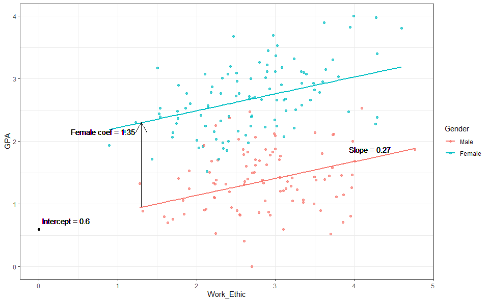

### LM with an interaction effect

Then, let’s make a model with an interaction between work ethic and gender. We can see that the coefficients for the intercept and main effect have changed.

```r
summary(GPA.Model.2)
```

```
Call:
lm(formula = GPA ~ Work_Ethic * Gender, data = GPA_data)

Residuals:
     Min       1Q   Median       3Q      Max
-1.35807 -0.36015  0.00458  0.32260  1.12149

Coefficients:
                        Estimate Std. Error t value Pr(>|t|)
(Intercept)              0.98106    0.20466   4.794 3.23e-06 ***
Work_Ethic               0.13972    0.06958   2.008  0.04602 *
GenderFemale             0.69482    0.26672   2.605  0.00989 **
Work_Ethic:GenderFemale  0.23580    0.09264   2.545  0.01169 *
---
Signif. codes:  0 ‘***’ 0.001 ‘**’ 0.01 ‘*’ 0.05 ‘.’ 0.1 ‘ ’ 1

Residual standard error: 0.4701 on 196 degrees of freedom
Multiple R-squared:  0.6856,    Adjusted R-squared:  0.6808
F-statistic: 142.5 on 3 and 196 DF,  p-value: < 2.2e-16
```

This time, we’ll use broom::augment() to predict the values, but add the annotations manually. Note that we’re using the exact same chunk of code when plotting the annotations (with the addition of the interaction value) - it works because we’re extracting the coefficients from the model fit, not just typing in the numbers.

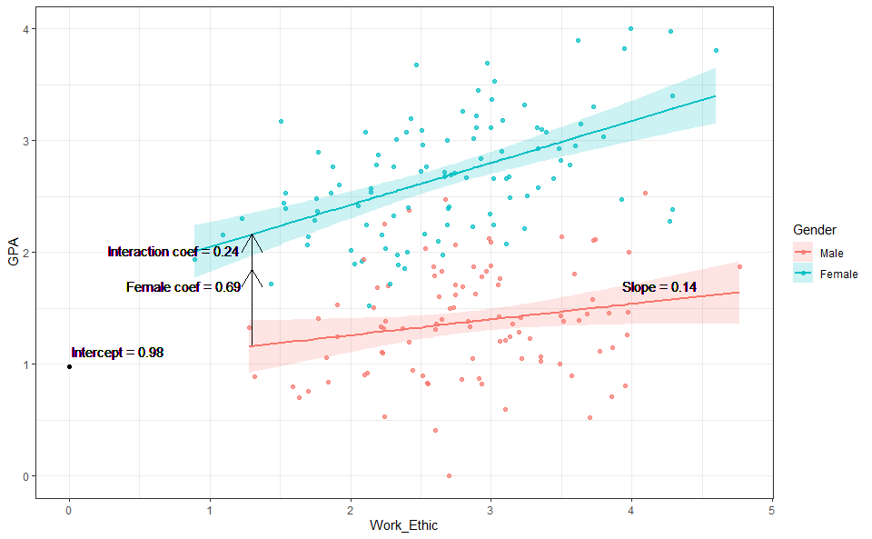

#### A note on centering

In the models above, we didn’t center the continuous predictor Work_ethic. If we had centered it, we would get a slightly different output:

```r
center <- function(variable) { # a function named center, with an argument variable
  centered_variable <- variable - mean(variable, na.rm=T) # define what the function does

  centered_variable # the last thing printed will be the function output
}

GPA.Model.3 <- lm(GPA ~ center(Work_Ethic) * Gender, GPA_data)

summary(GPA.Model.3)
```

[output not shown]

```r
mean(GPA_data$Work_Ethic)
```

[output not shown]

## Custom functions

R allows you to make your own functions, for example for making multiple plots in the same fashion. For example, let’s plot the predictions above using a function that takes the lm model as an argument (we’ll leave the annotations out for simplicity).

```r
# define the function here - it will show up in the Environment
my_plotting_function <- function(model) {

  GPA_plot <- broom::augment(model, se_fit = T) %>% # argument "model" goes here
  ggplot(aes(Work_Ethic, GPA)) +
  geom_point(aes(color = Gender), alpha = .7) +
  geom_line(aes(Work_Ethic, .fitted, color = Gender), size = 1) +
  geom_ribbon(aes(ymin=.fitted-1.96*.se.fit, ymax=.fitted+1.96*.se.fit, fill = Gender), alpha=0.2) +
  theme_bw()

  GPA_plot
}
```

```r
# use the function to plot predictions for a model
my_plotting_function(GPA.Model.1) # function_name(argument)
```

[output not shown]

If we want, we can make a list of plots from a list of models by using `lapply()`:

```r
lm_models <- list(GPA.Model.1, GPA.Model.2)

str(lm_models)

lm_plots <- lapply(lm_models, my_plotting_function)

lm_summary <- lapply(lm_models, summary)

lm_plots
```

[output not shown]